# vezbe01

## Vežbe 01 - Perceptron

### Učitavanje potrebnih biblioteka

```python
import numpy as np
import matplotlib.pyplot as plt

import numpy.random as rnd
```

### Generisanje podataka

Podaci su raspoređeni u dve klase, a svaku klasu definišu dva obeležja $x_1$ i $x_2$. Obeležja su generisani kao odbirci normalne raspodele, i to: $$ K_1: M_1 = \begin{bmatrix} 2 \\ 2 \end{bmatrix}, \text{ } \Sigma_1 = \begin{bmatrix} 1 & 0.3 \\ 0.3 & 1 \end{bmatrix}, \text{ } d_1 = 1 $$ $$ K_2: M_2 = \begin{bmatrix} 7 \\ 7 \end{bmatrix}, \text{ } \Sigma_2 = \begin{bmatrix} 0.9 & 0.2 \\ 0.2 & 0.6 \end{bmatrix}, \text{ } d_2 = 0 $$

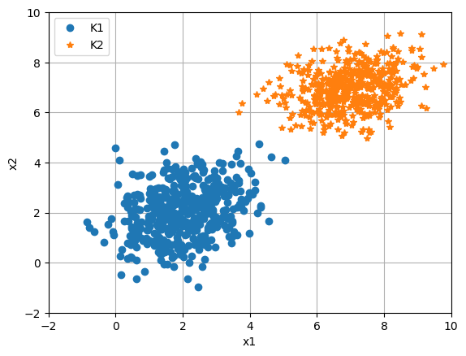

```python
# Generisanje odbiraka klase 1
N1 = 500
M1 = np.array([2, 2])
S1 = np.array([[1, 0.3], [0.3, 1]])
K1 = rnd.multivariate_normal(M1, S1, N1)
D1 = np.ones((N1, 1))

# Generisanje odbiraka klase 2
N2 = 500
M2 = np.array([7, 7])
S2 = np.array([[0.9, 0.2], [0.2, 0.6]])
K2 = rnd.multivariate_normal(M2, S2, N2)
D2 = np.zeros((N2, 1))

N = N1 + N2

# Prikaz podataka iz dve klasa
plt.figure()
plt.plot(K1[:, 0], K1[:, 1], 'o')
plt.plot(K2[:, 0], K2[:, 1], '*')
plt.xlabel('x1')
plt.ylabel('x2')
plt.xlim([-2, 10])
plt.ylim([-2, 10])
plt.grid()
plt.legend(['K1', 'K2'])
plt.show()
```

### Definisanje matrica ulaza i željenih izlaza

Ulazni skup podataka je formiran spajanjem merenja iz klase K1 i merenja iz klase K2. Na postojeća dva obležja $x_1$ i $x_2$ je dodata kolona koja predstavlja bias, tj. pomeraj, koji ima uvek vrednost $b = 1$.

Skup željenih izlaza je kreiran spajanjem željenih izlaza klase K1 i klase K2.

```python
# Kreiranje ulaza i željenog izlaza perceptrona
# Bias će biti predstavljen kao ulaz koji je uvek jednak jedinici
X = np.concatenate((K1, K2), axis=0)
bias = np.ones((N, 1))
X = np.concatenate((X, bias), axis=1)

D = np.concatenate((D1, D2), axis=0)
```

### Kreiranje i treniranje perceptrona

Kako je u pitanju problem klasifikacije oblika u dve klase, potrebno je kreirati LTU percetron koji se obučava perceptronskim pravilom obučavanja. Obzirom da su nam ulazi definisani kao $0$ i $1$, onda ćemo iskoristiit *step* funkciju aktivacije.

Tok obučavanja perceptrona se zasniva na ponavljanju nekoliko koraka:

1. Jedan element ulaznog skupa, $x_k$ prolazi kroz perceptron i formira $y_k$ (jedna iteracija obučavanja).
2. Formira se signal razlike na osnovu kog dolazi do promene težina. $$ r = d_k - y_k$$ $$ dW = \eta \cdot r \cdot x_k$$
3. Provera da li su prošli svi primerci ulaznog skupa (jedna epoha obučavanja). Ukoliko jesu, prelazi se na korak 4, a u suprotnom se vraća na korak 1.
4. Provera se da li je greška klasfikacije prihvatljiva. Ukoliko jeste završava se obučavanje, a ukoliko nije započinje se nova epoha treniranja.

Obučavanje može da se zaustavi i ako se dostigne maksimalan broj epoha treniranja.

```python
# Definisanje funkcije za računanje izlaza perceptrona
def predict(x, w):
    f = np.sum(w * x)
    if f >= 0:
        y = 1
    else:
        y = 0

    return y
```

```python
# Definisanje funkcije za računanje promene pojačanja
def weight_update(lr, d, y, x):
    dw = lr * (d - y) * x

    return dw
```

```python
# Definisanje funkcije za obučavanje perceptrona
def train_per(X, D, W, K, ep_max, lr, Emax, output=True):
    for ep in range(ep_max): # Sve epohe treniranja
        error = 0
        for k in range(K): # Svaki element ulaznog skupa
            x_k = np.reshape(X[k, :], (X.shape[1], 1))
            d_k = D[k, 0]

            y_k = predict(x_k, W)
            dW = weight_update(lr, d_k, y_k, x_k)
            W += dW

            # Računanje greške klasifikacije
            error += np.abs((d_k - y_k))

        # Normalizacija greške u odnosu na veličinu skupa podataka
        error /= K

        if output:
            print('Epoch=' + str(ep+1) + ', lrate=' + str(lr) +  ', error=' + str(error))

        # Ako greška padne ispod praga, zaustavlja se obučavanje
        if error < Emax:
            break

    return (W, error)
```

```python
# Definisanje parametara potrebnih za obučavanja
W = 0.1*rnd.randn(3, 1) # Početne težine
ep_max = 10 # Maksimalan broj epoha obučavanja
lr = 0.01 # Konstanta obučavanja
Emax = 0.002 # Maksimalna dozvoljena greška

W, _ = train_per(X, D, W, N, ep_max, lr, Emax)
```

```
Epoch=1, lrate=0.01, error=0.003
Epoch=2, lrate=0.01, error=0.005
Epoch=3, lrate=0.01, error=0.003
Epoch=4, lrate=0.01, error=0.003
Epoch=5, lrate=0.01, error=0.005
Epoch=6, lrate=0.01, error=0.003
Epoch=7, lrate=0.01, error=0.003
Epoch=8, lrate=0.01, error=0.004
Epoch=9, lrate=0.01, error=0.004
Epoch=10, lrate=0.01, error=0.004
```

### Prikaz granice odlučivanja

Granica odlučivanja je prava $h(x)$ koja razdvaja prostor obeležja na dva podprostora od kojih svaki odgovara jednoj klasi. Kako je perceptron linearni klasifikator, onda važi: $$ h(x) = \omega_1\cdot x_1 + \omega_2\cdot x_2 + \omega_b = 0 $$ Iz navedenog izraza sledi da je $$ x_2 = -\frac{\omega_1}{\omega_2}\cdot x_1 -\frac{\omega_b}{\omega_2} $$

```python
def granica_odlucivanja(W, start, stop):
    w1 = W[0]
    w2 = W[1]
    wb = W[2]

    x1 = np.linspace(start, stop)
    x2 = -w1*x1/w2 - wb/w2

    return x1, x2
```

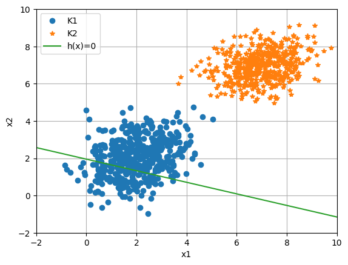

```python
x1go, x2go = granica_odlucivanja(W, start=-2, stop=10)

# Prikaz granice odlučivanja
plt.figure()
plt.plot(K1[:, 0], K1[:, 1], 'o')
plt.plot(K2[:, 0], K2[:, 1], '*')
plt.plot(x1go, x2go)
plt.xlabel('x1')
plt.ylabel('x2')
plt.xlim([-2, 10])
plt.ylim([-2, 10])
plt.grid()
plt.legend(['K1', 'K2', 'h(x)=0'])
plt.show()
```

Ukoliko više puta ponovimo treniranje perceptrona možemo primetiti da se granica odlučivanja ne nalazi uvek na istom mestu, što je glavna posledica nasumičnog postavljanja početnih težina.

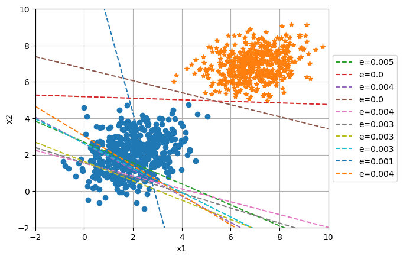

```python
plt.figure()
plt.plot(K1[:, 0], K1[:, 1], 'o')
plt.plot(K2[:, 0], K2[:, 1], '*')
for i in range(10):
    W = 0.1*rnd.randn(3, 1)

    W, error = train_per(X, D, W, N, ep_max, lr, Emax, output=False)

    x1go, x2go = granica_odlucivanja(W, start=-2, stop=10)

    plt.plot(x1go, x2go, '--', label='e=%s' % error)

plt.legend(loc='center left', bbox_to_anchor=(1, 0.5))
plt.xlim([-2, 10])
plt.ylim([-2, 10])
plt.xlabel('x1')
plt.ylabel('x2')
plt.grid()
plt.show()
```

### Ispravna greška klasifikacije

Greška koju dobijamo na kraju treniranja je mala, što ukazuje na odlične performanse perceptrona. Međutim vidimo da je u većem broju slučajeva granica odlučivanja postavljena tako da je značajno veći broj odbiraka pogrešno klasifikovan. Da bismo videli stvarnu uspešnost klasifikacije, potrebno je da nakon treniranja ponovo izvršimo predikciju nad celim skupom podataka, sa finalnim težinama, i da tada izračunamo grešku klasifikacije.

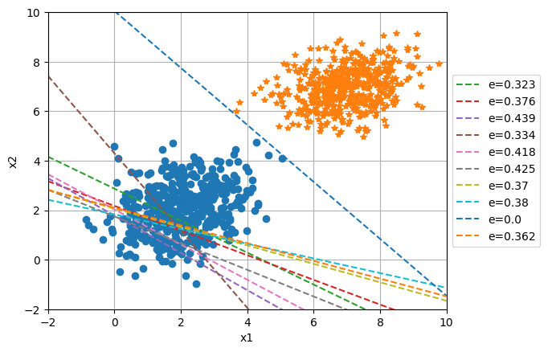

```python
plt.figure()
plt.plot(K1[:, 0], K1[:, 1], 'o')
plt.plot(K2[:, 0], K2[:, 1], '*')
for i in range(10):
    W = 0.1*rnd.randn(3, 1)

    W, _ = train_per(X, D, W, N, ep_max, lr, Emax, output=False)

    # Računanje greške nakon treniranja
    error = 0
    for k in range(N):
        x_k = np.reshape(X[k, :], (X.shape[1], 1))
        d_k = D[k, 0]
        y_k = predict(x_k, W)
        error += np.abs(d_k - y_k)

    error /= N1 + N2

    x1go, x2go = granica_odlucivanja(W, start=-2, stop=10)

    plt.plot(x1go, x2go, '--', label='e=%s' % error)

plt.legend(loc='center left', bbox_to_anchor=(1, 0.5))
plt.xlabel('x1')
plt.ylabel('x2')
plt.xlim([-2, 10])
plt.ylim([-2, 10])
plt.grid()
plt.show()
```

### Mešanje podataka

Možemo primetiti da je granica odlučivanja uvek postavljena tako da su odbirci iz klase $K_2$ u potpunosti ispravno klasifikovani. Razlog tome je to što je ulazni skupa $X$ napravljen tako da se u prvom bloku nalaze podaci iz klase $K_1$, a zatim iz klase $K_2$, te se perceptron prvo podešava prema prvoj klasi, a zatim se koriguje na osnovu podataka iz druge klase.

Kako bi se sprečilo navikavanje percetprona na podatke samo jedne od klasa, odnosno kako bi se sprečilo da je perceptron na kraju obučavanja prilagođen podacima iz klase $K_2$, potrebno je pre samog procesa treniranja promešamo podatke iz ulaznog skupa podataka. Pri mešanju podataka treba voditi računa da se i ulazni podaci i željeni izlazi mešaju na isti način.

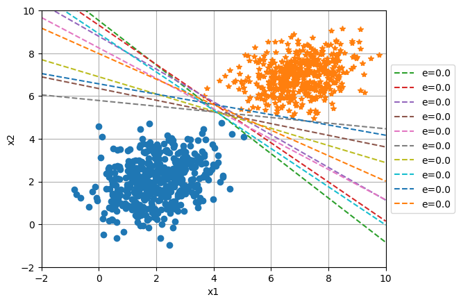

```python
idx = rnd.permutation(N)
Xrand = X[idx, :]
Drand = D[idx, :]

plt.figure()
plt.plot(K1[:, 0], K1[:, 1], 'o')
plt.plot(K2[:, 0], K2[:, 1], '*')
for i in range(10):
    W = 0.1*rnd.randn(3, 1) # Početne težine

    W, _ = train_per(Xrand, Drand, W, N, ep_max, lr, Emax, output=False)

    # Računanje greške nakon treniranja
    error = 0
    for k in range(N):
        x_k = np.reshape(Xrand[k, :], (Xrand.shape[1], 1))
        d_k = Drand[k, 0]
        y_k = predict(x_k, W)
        error += np.abs(d_k - y_k)

    error /= N1 + N2

    x1go, x2go = granica_odlucivanja(W, start=-2, stop=10)

    plt.plot(x1go, x2go, '--', label='e=%s' % error)

plt.legend(loc='center left', bbox_to_anchor=(1, 0.5))
plt.xlabel('x1')
plt.ylabel('x2')
plt.xlim([-2, 10])
plt.ylim([-2, 10])
plt.grid()
plt.show()
```